# 7 Data wrangling

As with data visualization, data wrangling is a fundamental part of being able to accurately, reproducibly, and efficiently work with data. The approach taken in the following chapter is based on the philosophy of tidy data and takes many of its precepts from database theory. If you have done much work in SQL, the functionality and approach of tidy data will feel very familiar. The more adept you are at data wrangling, the more effective you will be at data analysis.

> Information is what we want, but data are what we’ve got. (Kaplan 2015)

**Embrace all the ways to get help!**

1. cheatsheets: https://opensource.posit.co/resources/cheatsheets/?languages=R
2. tidyverse vignettes: https://cran.r-project.org/web/packages/tidyverse/vignettes/paper.html
3. pivoting: https://tidyr.tidyverse.org/articles/pivot.html
4. google what you need and include `R tidy` or `tidyverse`

## 7.1 Coding Style

An important aspect of the data wrangling tools in this chapter includes best practices for writing code. The tidyverse style of coding allows you to implement code that is clean and communicates ideas easily. The more your code conforms to a style, the easier it will be to debug, and the fewer mistakes you will make. Understanding the rules of programming discourse is part of what makes excellent coders. (Soloway and Ehrlich 1984)

> Good coding style is like correct punctuation: you can manage without it, butitsuremakesthingseasiertoread. [The tidyverse style guide](https://style.tidyverse.org/)

### 7.1.1 Why do style and format matter?

Consistency and communication are very important aspects of coding. While the computer does not usually care about code style, the computer is not the only entity working in the coding space. Humans play a huge role in making code work, and they absolutely do better in situations where style is consistent and clear.

In chess, experienced players have excellent memories for recall of specific games and positions they have seen previously. However, recall is substantially better for situations with regular patterns as opposed to remembering random positions. (Gobet and Simon 1996) The related psychological idea, chunking, states that small pieces of information improve long-term retention of the material. When code is random or unwieldy, the coder has to use more brainpower to process the intent of the code.

In particular, good code style:

- highlights where the errors are.
- makes it easier to fix errors.
- focuses the reader’s eye on what the code is doing (bad style obscures the information into the code itself).
- helps the future reader of the code (which is likely you in the future!) understand what the code does.
- follows the rules that specify conventions in programming.

### 7.1.2 Best practices for writing good code.

A style guide is a set of rules and best practices that help coders write code. There are no absolute *truths* when it comes to style, but consistency is important for being able to communicate your work.

1. Use a style guide. For example, try [The tidyverse style guide](https://style.tidyverse.org/)
2. Use the same guide that your collaborators are using – remember, communication is key!

## 7.2 Structure of Data

For plotting, analyses, model building, etc., it’s important that the data be structured in a very particular way. Hadley Wickham provides a thorough discussion and advice for cleaning up the data in Wickham (2014).

- *Tidy Data*: rows (cases/observational units) and columns (variables). The key is that *every* row is a case and *every} column is a variable. No exceptions.
- Creating tidy data is not trivial. We work with objects (often data tables), functions, and arguments (often variables).

The Active Duty data are not tidy! What are the cases? How are the data not tidy? What might the data look like in tidy form? Suppose that the case was “an individual in the armed forces.” What variables would you use to capture the information in the following table?

https://docs.google.com/spreadsheets/d/1Ow6Cm4z-Z1Yybk3i352msulYCEDOUaOghmo9ALajyHo/edit#gid=1811988794

[figure not shown]

**Problem:** totals and different sheets

**Better for R:** longer format with columns - grade, gender, status, service, count (case is still the total pay grade)

**Case is individual (?)**: grade, gender, status, service (no count because each row does the counting)

### 7.2.1 Building Tidy Data

Within R (really within any type of computing language, Python, SQL, Java, etc.), we need to understand how to build data using the patterns of the language. Some things to consider:

- `object_name = function_name(arguments)` is a way of using a function to create a new object.
- `object_name = data_table |> function_name(arguments)` uses chaining syntax as an extension of the ideas of functions. In chaining, the value on the left side of `|>` becomes the *first argument* to the function on the right side.

```
object_name = data_table |>
function_name(arguments) |>
function_name(arguments)
```

is extended chaining. `|>` is never at the front of the line, it is always connecting one idea with the continuation of that idea on the next line. * In R, all functions take arguments in round parentheses (as opposed to subsetting observations or variables from data objects which happen with square parentheses). Additionally, the spot to the left of `|>` is always a data table. * The pipe syntax should be read as *then*, `|>`.

### 7.2.2 Examples of Chaining

The pipe syntax (`|>`) takes a data frame (or data table) and sends it to the argument of a function. The mapping goes to the first available argument in the function. For example:

`x |> f()` is the same as `f(x)`

`x |> f(y)` is the same as `f(x, y)`

#### 7.2.2.1 Little Bunny Foo Foo

From Hadley Wickham, how to think about tidy data.

> Little bunny Foo Foo Went hopping through the forest Scooping up the field mice And bopping them on the head

The nursery rhyme could be created by a series of steps where the output from each step is saved as an object along the way.

```
foo_foo <- little_bunny()
foo_foo_1 <- hop(foo_foo, through = forest)
foo_foo_2 <- scoop(foo_foo_2, up = field_mice)
foo_foo_3 <- bop(foo_foo_2, on = head)
```

Another approach is to concatenate the functions so that there is only one output.

```
bop(
   scoop(
      hop(foo_foo, through = forest),
      up = field_mice),
   on = head)
```

Or even worse, as one line:

```
bop(scoop(hop(foo_foo, through = forest), up = field_mice), on = head)))
```

Instead, the code can be written using the pipe in the **order** in which the function is evaluated:

```
foo_foo |>
   hop(through = forest) |>
       scoop(up = field_mice) |>
           bop(on = head)
```

**babynames** Each year, the US Social Security Administration publishes a list of the most popular names given to babies. In 2014, http://www.ssa.gov/oact/babynames/#ht=2 shows Emma and Olivia leading for girls, Noah and Liam for boys.

The `babynames` data table in the `babynames` package comes from the Social Security Administration’s listing of the names givens to babies in each year, and the number of babies of each sex given that name. (Only names with 5 or more babies are published by the SSA.)

### 7.2.3 Data Verbs (on single data frames)

> Super important resource: The Positron **dplyr** cheatsheet: https://opensource.posit.co/resources/cheatsheets/data-transformation/

**Data verbs take data tables as input and give data tables as output (that’s how we can use the chaining syntax!).** We will use the R package **dplyr** to do much of our data wrangling. Below is a list of verbs which will be helpful in wrangling many different types of data. See the Data Wrangling cheat sheet from Positron for additional help. https://opensource.posit.co/resources/cheatsheets/data-transformation/

- `sample_n()` take a random row(s)
- `head()` grab the first few rows
- `tail()` grab the last few rows
- `filter()` removes unwanted *cases*
- `arrange()` reorders the cases
- `select()` removes unwanted *variables* (and `rename()` )
- `distinct()` returns the unique values in a table
- `mutate()` transforms the variable (and `transmute()` like mutate, returns only new variables)
- `group_by()` tells R that SUCCESSIVE functions keep in mind that there are groups of items. So `group_by()` only makes sense with verbs later on (like `summarize()`).
- `summarize()` collapses a data frame to a single row. Some functions that are used within `summarize()` include:
  - `min(), max(), mean(), sum(), sd(), median()`, and `IQR()`
  - `n()`: number of observations in the current group
  - `n_distinct(x)`: count the number of unique values in `x`
  - `first_value(x), last_value(x)` and `nth_value(x, n)`: work similarly to `x[1], x[length(x)]`, and `x[n]`

## 7.3 R examples, basic verbs

### 7.3.1 Datasets

`starwars` is from **dplyr** , although originally from SWAPI, the Star Wars API, http://swapi.co/.

`NHANES` From `?NHANES`: NHANES is survey data collected by the US National Center for Health Statistics (NCHS) which has conducted a series of health and nutrition surveys since the early 1960’s. Since 1999 approximately 5,000 individuals of all ages are interviewed in their homes every year and complete the health examination component of the survey. The health examination is conducted in a mobile examination center (MEC).

`babynames` Each year, the US Social Security Administration publishes a list of the most popular names given to babies. In 2018, http://www.ssa.gov/oact/babynames/#ht=2 shows Emma and Olivia leading for girls, Noah and Liam for boys. (Only names with 5 or more babies are published by the SSA.)

### 7.3.2 Examples of Chaining

```r
library(babynames)
babynames |> nrow()
```

```
[1] 1924665
```

```r
babynames |> names()
```

```
[1] "year" "sex"  "name" "n"    "prop"
```

```r
babynames |> glimpse()
```

```
Rows: 1,924,665
Columns: 5
$ year <dbl> 1880, 1880, 1880, 1880, 1880, 1880, 1880, 1880, 1880, 1880, 1880,…
$ sex  <chr> "F", "F", "F", "F", "F", "F", "F", "F", "F", "F", "F", "F", "F", …
$ name <chr> "Mary", "Anna", "Emma", "Elizabeth", "Minnie", "Margaret", "Ida",…
$ n    <int> 7065, 2604, 2003, 1939, 1746, 1578, 1472, 1414, 1320, 1288, 1258,…
$ prop <dbl> 0.07238, 0.02668, 0.02052, 0.01987, 0.01789, 0.01617, 0.01508, 0.…
```

```r
babynames |> head()
```

```
# A tibble: 6 × 5
   year sex   name          n   prop
  <dbl> <chr> <chr>     <int>  <dbl>
1  1880 F     Mary       7065 0.0724
2  1880 F     Anna       2604 0.0267
3  1880 F     Emma       2003 0.0205
4  1880 F     Elizabeth  1939 0.0199
5  1880 F     Minnie     1746 0.0179
6  1880 F     Margaret   1578 0.0162
```

```r
babynames |> tail()
```

```
# A tibble: 6 × 5
   year sex   name       n       prop
  <dbl> <chr> <chr>  <int>      <dbl>
1  2017 M     Zyhier     5 0.00000255
2  2017 M     Zykai      5 0.00000255
3  2017 M     Zykeem     5 0.00000255
4  2017 M     Zylin      5 0.00000255
5  2017 M     Zylis      5 0.00000255
6  2017 M     Zyrie      5 0.00000255
```

```r
babynames |> sample_n(size = 5)
```

```
# A tibble: 5 × 5
   year sex   name         n       prop
  <dbl> <chr> <chr>    <int>      <dbl>
1  1947 M     Modesto     23 0.0000124
2  2007 F     Cytlali      8 0.00000378
3  2009 F     Haniyyah     7 0.00000346
4  1951 M     Emiliano    11 0.00000575
5  2009 M     Kayshon      5 0.00000236
```

#### 7.3.2.1 Order matters!

Notice below that the value of `mean_delay` is different for the two queries.

##### Order 1: filter first, then mutate

```r
library(nycflights13)
flights |>
  filter(dep_delay > 500) |>
  group_by(carrier) |>
  mutate(mean_delay = mean(dep_delay, na.rm = TRUE)) |>
  select(year, month, day, dep_delay, mean_delay, origin, dest, carrier)
```

```
# A tibble: 60 × 8
# Groups:   carrier [10]
   year month   day dep_delay mean_delay origin dest  carrier
  <int> <int> <int>     <dbl>      <dbl> <chr>  <chr> <chr>
1  2013     1     1       853      1000. JFK    BWI   MQ
2  2013     1     9      1301      1301  JFK    HNL   HA
3  2013     1    10      1126      1000. EWR    ORD   MQ
4  2013     1    13       599       716. JFK    ATL   DL
5  2013     1    16       502       502  EWR    MCO   B6
6  2013    10    14       702       716. EWR    ATL   DL
# ℹ 54 more rows
```

##### Order 2: mutate first, then filter

```r
flights |>
  group_by(carrier) |>
  mutate(mean_delay = mean(dep_delay, na.rm = TRUE)) |>
  filter(dep_delay > 500) |>
  select(year, month, day, dep_delay, mean_delay, origin, dest, carrier)
```

```
# A tibble: 60 × 8
# Groups:   carrier [10]
   year month   day dep_delay mean_delay origin dest  carrier
  <int> <int> <int>     <dbl>      <dbl> <chr>  <chr> <chr>
1  2013     1     1       853      10.6  JFK    BWI   MQ
2  2013     1     9      1301       4.90 JFK    HNL   HA
3  2013     1    10      1126      10.6  EWR    ORD   MQ
4  2013     1    13       599       9.26 JFK    ATL   DL
5  2013     1    16       502      13.0  EWR    MCO   B6
6  2013    10    14       702       9.26 EWR    ATL   DL
# ℹ 54 more rows
```

### 7.3.3 Data Verbs

Taken from the dplyr tutorial: https://dplyr.tidyverse.org/

#### 7.3.3.1 Starwars

```r
library(dplyr)

starwars |> dim()
```

```
[1] 87 14
```

```r
starwars |> names()
```

```
 [1] "name"       "height"     "mass"       "hair_color" "skin_color"
 [6] "eye_color"  "birth_year" "sex"        "gender"     "homeworld"
[11] "species"    "films"      "vehicles"   "starships"
```

```r
starwars |> head()
```

```
# A tibble: 6 × 14
  name      height  mass hair_color skin_color eye_color birth_year sex   gender
  <chr>      <int> <dbl> <chr>      <chr>      <chr>          <dbl> <chr> <chr>
1 Luke Sky…    172    77 blond      fair       blue            19   male  mascu…
2 C-3PO        167    75 <NA>       gold       yellow         112   none  mascu…
3 R2-D2         96    32 <NA>       white, bl… red             33   none  mascu…
4 Darth Va…    202   136 none       white      yellow          41.9 male  mascu…
5 Leia Org…    150    49 brown      light      brown           19   fema… femin…
6 Owen Lars    178   120 brown, gr… light      blue            52   male  mascu…
# ℹ 5 more variables: homeworld <chr>, species <chr>, films <list>,
#   vehicles <list>, starships <list>
```

```r
starwars |>
  dplyr::filter(species == "Droid")
```

```
# A tibble: 6 × 14
  name   height  mass hair_color skin_color  eye_color birth_year sex   gender
  <chr>   <int> <dbl> <chr>      <chr>       <chr>          <dbl> <chr> <chr>
1 C-3PO     167    75 <NA>       gold        yellow           112 none  masculi…
2 R2-D2      96    32 <NA>       white, blue red               33 none  masculi…
3 R5-D4      97    32 <NA>       white, red  red               NA none  masculi…
4 IG-88     200   140 none       metal       red               15 none  masculi…
5 R4-P17     96    NA none       silver, red red, blue         NA none  feminine
6 BB8        NA    NA none       none        black             NA none  masculi…
# ℹ 5 more variables: homeworld <chr>, species <chr>, films <list>,
#   vehicles <list>, starships <list>
```

```r
starwars |>
  dplyr::select(name, ends_with("color"))
```

```
# A tibble: 87 × 4
  name           hair_color  skin_color  eye_color
  <chr>          <chr>       <chr>       <chr>
1 Luke Skywalker blond       fair        blue
2 C-3PO          <NA>        gold        yellow
3 R2-D2          <NA>        white, blue red
4 Darth Vader    none        white       yellow
5 Leia Organa    brown       light       brown
6 Owen Lars      brown, grey light       blue
# ℹ 81 more rows
```

```r
starwars |>
  dplyr::mutate(name, bmi = mass / ((height / 100)^2)) |>
  dplyr::select(name:mass, bmi)
```

```
# A tibble: 87 × 4
  name           height  mass   bmi
  <chr>           <int> <dbl> <dbl>
1 Luke Skywalker    172    77  26.0
2 C-3PO             167    75  26.9
3 R2-D2              96    32  34.7
4 Darth Vader       202   136  33.3
5 Leia Organa       150    49  21.8
6 Owen Lars         178   120  37.9
# ℹ 81 more rows
```

```r
starwars |>
  dplyr::arrange(desc(mass))
```

```
# A tibble: 87 × 14
  name      height  mass hair_color skin_color eye_color birth_year sex   gender
  <chr>      <int> <dbl> <chr>      <chr>      <chr>          <dbl> <chr> <chr>
1 Jabba De…    175  1358 <NA>       green-tan… orange         600   herm… mascu…
2 Grievous     216   159 none       brown, wh… green, y…       NA   male  mascu…
3 IG-88        200   140 none       metal      red             15   none  mascu…
4 Darth Va…    202   136 none       white      yellow          41.9 male  mascu…
5 Tarfful      234   136 brown      brown      blue            NA   male  mascu…
6 Owen Lars    178   120 brown, gr… light      blue            52   male  mascu…
# ℹ 81 more rows
# ℹ 5 more variables: homeworld <chr>, species <chr>, films <list>,
#   vehicles <list>, starships <list>
```

```r
starwars |>
  dplyr::group_by(species) |>
  dplyr::summarize(
    num = n(),
    mass = mean(mass, na.rm = TRUE)
  ) |>
  dplyr::filter(num > 1)
```

```
# A tibble: 9 × 3
  species    num  mass
  <chr>    <int> <dbl>
1 Droid        6  69.8
2 Gungan       3  74
3 Human       35  81.3
4 Kaminoan     2  88
5 Mirialan     2  53.1
6 Twi'lek      2  55
# ℹ 3 more rows
```

#### 7.3.3.2 NHANES

```r
library(NHANES)
names(NHANES)
```

```
 [1] "ID"               "SurveyYr"         "Gender"           "Age"
 [5] "AgeDecade"        "AgeMonths"        "Race1"            "Race3"
 [9] "Education"        "MaritalStatus"    "HHIncome"         "HHIncomeMid"
[13] "Poverty"          "HomeRooms"        "HomeOwn"          "Work"
[17] "Weight"           "Length"           "HeadCirc"         "Height"
[21] "BMI"              "BMICatUnder20yrs" "BMI_WHO"          "Pulse"
[25] "BPSysAve"         "BPDiaAve"         "BPSys1"           "BPDia1"
[29] "BPSys2"           "BPDia2"           "BPSys3"           "BPDia3"
[33] "Testosterone"     "DirectChol"       "TotChol"          "UrineVol1"
[37] "UrineFlow1"       "UrineVol2"        "UrineFlow2"       "Diabetes"
[41] "DiabetesAge"      "HealthGen"        "DaysPhysHlthBad"  "DaysMentHlthBad"
[45] "LittleInterest"   "Depressed"        "nPregnancies"     "nBabies"
[49] "Age1stBaby"       "SleepHrsNight"    "SleepTrouble"     "PhysActive"
[53] "PhysActiveDays"   "TVHrsDay"         "CompHrsDay"       "TVHrsDayChild"
[57] "CompHrsDayChild"  "Alcohol12PlusYr"  "AlcoholDay"       "AlcoholYear"
[61] "SmokeNow"         "Smoke100"         "Smoke100n"        "SmokeAge"
[65] "Marijuana"        "AgeFirstMarij"    "RegularMarij"     "AgeRegMarij"
[69] "HardDrugs"        "SexEver"          "SexAge"           "SexNumPartnLife"
[73] "SexNumPartYear"   "SameSex"          "SexOrientation"   "PregnantNow"
```

```r
# find the sleep variables
NHANESsleep <- NHANES |>
  select(
    Gender,
    Age,
    Weight,
    Race1,
    Race3,
    Education,
    SleepTrouble,
    SleepHrsNight,
    TVHrsDay,
    TVHrsDayChild,
    PhysActive
  )
names(NHANESsleep)
```

```
 [1] "Gender"        "Age"           "Weight"        "Race1"
 [5] "Race3"         "Education"     "SleepTrouble"  "SleepHrsNight"
 [9] "TVHrsDay"      "TVHrsDayChild" "PhysActive"
```

```r
dim(NHANESsleep)
```

```
[1] 10000    11
```

```r
# subset for college students
NHANESsleep <- NHANESsleep |>
  filter(Age %in% c(18:22)) |>
  mutate(Weightlb = Weight * 2.2)

names(NHANESsleep)
```

```
 [1] "Gender"        "Age"           "Weight"        "Race1"
 [5] "Race3"         "Education"     "SleepTrouble"  "SleepHrsNight"
 [9] "TVHrsDay"      "TVHrsDayChild" "PhysActive"    "Weightlb"
```

```r
dim(NHANESsleep)
```

```
[1] 655  12
```

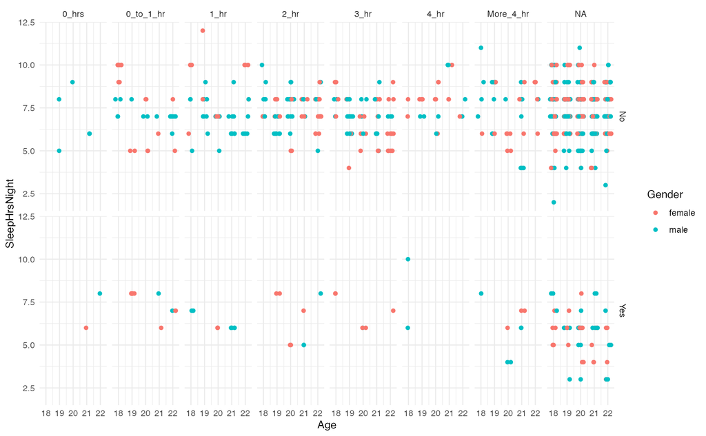

```r
NHANESsleep |>
  ggplot(aes(x = Age, y = SleepHrsNight, color = Gender)) +
  geom_point(position = position_jitter(width = .25, height = 0)) +
  facet_grid(SleepTrouble ~ TVHrsDay) +
  theme_minimal()
```

### 7.3.4 `summarize` and `group_by`

```r
# number of people (cases) in NHANES
NHANES |> summarize(n())
```

```
# A tibble: 1 × 1
  `n()`
  <int>
1 10000
```

```r
# total weight of all the people in NHANES (silly)
NHANES |>
  mutate(Weightlb = Weight * 2.2) |>
  summarize(sum(Weightlb, na.rm = TRUE))
```

```
# A tibble: 1 × 1
  `sum(Weightlb, na.rm = TRUE)`
                          <dbl>
1                      1549419.
```

```r
# mean weight of all the people in NHANES
NHANES |>
  mutate(Weightlb = Weight * 2.2) |>
  summarize(mean(Weightlb, na.rm = TRUE))
```

```
# A tibble: 1 × 1
  `mean(Weightlb, na.rm = TRUE)`
                           <dbl>
1                           156.
```

```r
# repeat the above but for groups

# males versus females
NHANES |> group_by(Gender) |> summarize(n())
```

```
# A tibble: 2 × 2
  Gender `n()`
  <fct>  <int>
1 female  5020
2 male    4980
```

```r
NHANES |>
  group_by(Gender) |>
  mutate(Weightlb = Weight * 2.2) |>
  summarize(mean(Weightlb, na.rm = TRUE))
```

```
# A tibble: 2 × 2
  Gender `mean(Weightlb, na.rm = TRUE)`
  <fct>                           <dbl>
1 female                           146.
2 male                             167.
```

```r
# smokers and non-smokers
NHANES |> group_by(SmokeNow) |> summarize(n())
```

```
# A tibble: 3 × 2
  SmokeNow `n()`
  <fct>    <int>
1 No        1745
2 Yes       1466
3 <NA>      6789
```

```r
NHANES |>
  group_by(SmokeNow) |>
  mutate(Weightlb = Weight * 2.2) |>
  summarize(mean(Weightlb, na.rm = TRUE))
```

```
# A tibble: 3 × 2
  SmokeNow `mean(Weightlb, na.rm = TRUE)`
  <fct>                             <dbl>
1 No                                 186.
2 Yes                                177.
3 <NA>                               144.
```

```r
# people with and without diabetes
NHANES |> group_by(Diabetes) |> summarize(n())
```

```
# A tibble: 3 × 2
  Diabetes `n()`
  <fct>    <int>
1 No        9098
2 Yes        760
3 <NA>       142
```

```r
NHANES |>
  group_by(Diabetes) |>
  mutate(Weightlb = Weight * 2.2) |>
  summarize(mean(Weightlb, na.rm = TRUE))
```

```
# A tibble: 3 × 2
  Diabetes `mean(Weightlb, na.rm = TRUE)`
  <fct>                             <dbl>
1 No                                155.
2 Yes                               202.
3 <NA>                               21.6
```

```r
# break down the smokers versus non-smokers further, by sex
NHANES |> group_by(SmokeNow, Gender) |> summarize(n())
```

```
# A tibble: 6 × 3
# Groups:   SmokeNow [3]
  SmokeNow Gender `n()`
  <fct>    <fct>  <int>
1 No       female   764
2 No       male     981
3 Yes      female   638
4 Yes      male     828
5 <NA>     female  3618
6 <NA>     male    3171
```

```r
NHANES |>
  group_by(SmokeNow, Gender) |>
  mutate(Weightlb = Weight * 2.2) |>
  summarize(mean(Weightlb, na.rm = TRUE))
```

```
# A tibble: 6 × 3
# Groups:   SmokeNow [3]
  SmokeNow Gender `mean(Weightlb, na.rm = TRUE)`
  <fct>    <fct>                           <dbl>
1 No       female                           167.
2 No       male                             201.
3 Yes      female                           167.
4 Yes      male                             185.
5 <NA>     female                           138.
6 <NA>     male                             151.
```

```r
# break down the people with diabetes further, by smoking
NHANES |> group_by(Diabetes, SmokeNow) |> summarize(n())
```

```
# A tibble: 8 × 3
# Groups:   Diabetes [3]
  Diabetes SmokeNow `n()`
  <fct>    <fct>    <int>
1 No       No        1476
2 No       Yes       1360
3 No       <NA>      6262
4 Yes      No         267
5 Yes      Yes        106
6 Yes      <NA>       387
# ℹ 2 more rows
```

```r
NHANES |>
  group_by(Diabetes, SmokeNow) |>
  mutate(Weightlb = Weight * 2.2) |>
  summarize(mean(Weightlb, na.rm = TRUE))
```

```
# A tibble: 8 × 3
# Groups:   Diabetes [3]
  Diabetes SmokeNow `mean(Weightlb, na.rm = TRUE)`
  <fct>    <fct>                             <dbl>
1 No       No                                 183.
2 No       Yes                                175.
3 No       <NA>                               143.
4 Yes      No                                 204.
5 Yes      Yes                                204.
6 Yes      <NA>                               199.
# ℹ 2 more rows
```

### 7.3.5 babynames

```r
babynames |> group_by(sex) |> summarize(total = sum(n))
```

```
# A tibble: 2 × 2
  sex       total
  <chr>     <int>
1 F     172371079
2 M     175749438
```

```r
babynames |>
  group_by(year, sex) |>
  summarize(name_count = n_distinct(name)) |>
  head()
```

```
# A tibble: 6 × 3
# Groups:   year [3]
   year sex   name_count
  <dbl> <chr>      <int>
1  1880 F            942
2  1880 M           1058
3  1881 F            938
4  1881 M            997
5  1882 F           1028
6  1882 M           1099
```

```r
babynames |>
  group_by(year, sex) |>
  summarize(name_count = n_distinct(name)) |>
  tail()
```

```
# A tibble: 6 × 3
# Groups:   year [3]
   year sex   name_count
  <dbl> <chr>      <int>
1  2015 F          19074
2  2015 M          14024
3  2016 F          18817
4  2016 M          14162
5  2017 F          18309
6  2017 M          14160
```

```r
babysamp <- babynames |> sample_n(size = 50)
babysamp |> select(year) |> distinct() |> table()
```

```
year
1918 1923 1926 1933 1949 1950 1951 1954 1956 1957 1959 1964 1969 1972 1973 1975
   1    1    1    1    1    1    1    1    1    1    1    1    1    1    1    1
1980 1984 1986 1987 1989 1991 1992 1993 1994 1996 1997 1999 2002 2004 2006 2007
   1    1    1    1    1    1    1    1    1    1    1    1    1    1    1    1
2008 2013 2015 2016
   1    1    1    1
```

```r
babysamp |> distinct() |> select(year) |> table()
```

```
year
1918 1923 1926 1933 1949 1950 1951 1954 1956 1957 1959 1964 1969 1972 1973 1975
   1    2    1    1    1    1    1    2    1    1    2    1    1    2    1    1
1980 1984 1986 1987 1989 1991 1992 1993 1994 1996 1997 1999 2002 2004 2006 2007
   1    1    1    2    1    2    1    2    1    3    1    1    1    2    1    2
2008 2013 2015 2016
   1    1    4    1
```

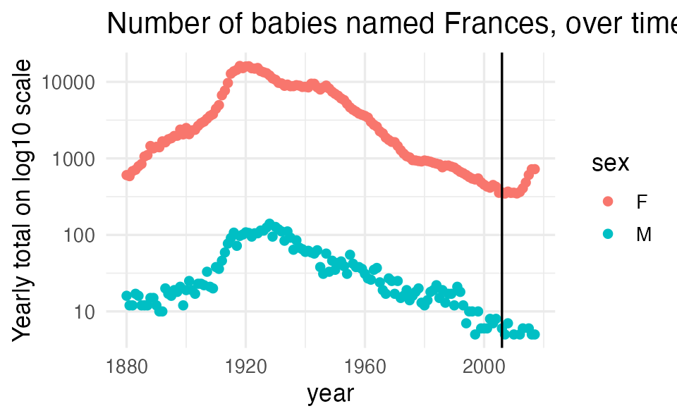

```r
Frances <- babynames |>
  filter(name == "Frances") |>
  group_by(year, sex) |>
  summarize(yrTot = sum(n))

Frances |>
  ggplot(aes(x = year, y = yrTot)) +
  geom_point(aes(color = sex)) +
  geom_vline(xintercept = 2006) +
  scale_y_log10() +
  labs(
    y = "Yearly total on log10 scale",
    title = "Number of babies named Frances, over time"
  )
```

## 7.4 Higher Level Data Verbs

There are more complicated verbs which may be important for more sophisticated analyses. See the Positron **dplyr** cheatsheet, https://opensource.posit.co/resources/cheatsheets/data-transformation/.

- `pivot_longer` makes many columns into 2 columns: `pivot_longer(data, cols, names_to = , value_to = )`
- `pivot_wider` makes one column into multiple columns: `pivot_wider(data, names_from = , values_from = )`
- `left_join` returns all rows from the left table, and any rows with matching keys from the right table.
- `inner_join` returns only the rows in which the left table have matching keys in the right table (i.e., matching rows in both sets).
- `full_join` returns all rows from both tables, join records from the left which have matching keys in the right table.

Good practice: always specify the `by` argument when joining data frames.

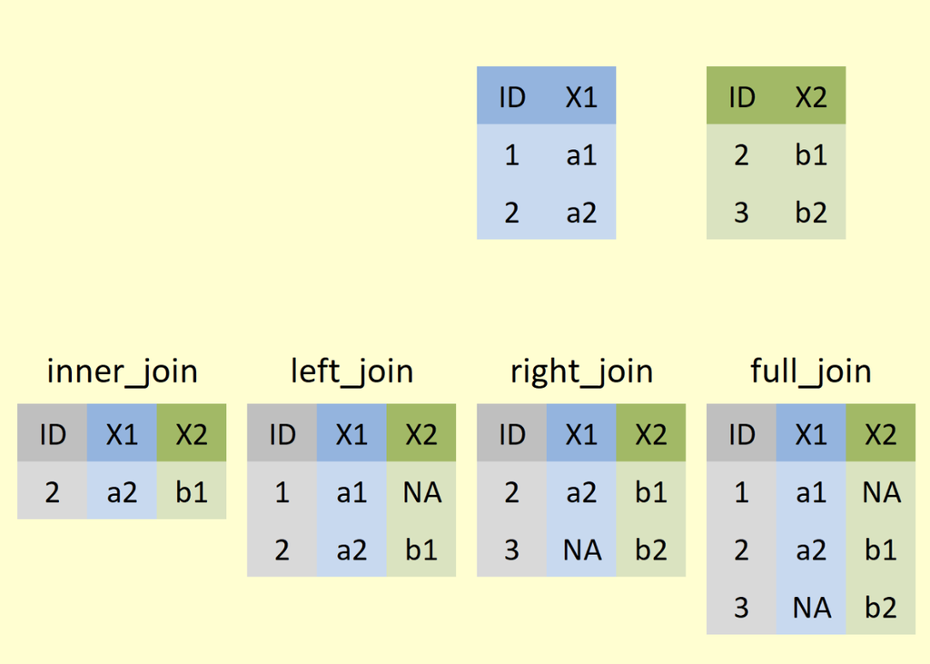

If you ever need to understand which join is the right join for you, try to find an image that will lay out what the function is doing. I found this one that is quite good and is taken from Statistics Globe blog: https://statisticsglobe.com/r-dplyr-join-inner-left-right-full-semi-anti

## 7.5 R examples, higher level verbs

**tidyr** 1.0.0 has just been released! The new release means that you need to update **tidyr**. You will know if you have the latest version if the following command works in the console (window below):

```
?tidyr::pivot_longer
```

If you are familiar with `spread` and `gather`, you should acquaint yourself with `pivot_longer()` and `pivot_wider()`. The idea is to go from very wide dataframes to very long dataframes and vice versa.

### 7.5.1 `pivot_longer()`

`pivot` the military pay grade to become longer?

[figure not shown]

https://docs.google.com/spreadsheets/d/1Ow6Cm4z-Z1Yybk3i352msulYCEDOUaOghmo9ALajyHo/edit# gid=1811988794

```r
library(googlesheets4)
gs4_deauth()

navy_gs <- read_sheet(
  "https://docs.google.com/spreadsheets/d/1Ow6Cm4z-Z1Yybk3i352msulYCEDOUaOghmo9ALajyHo/edit#gid=1877566408",
  col_types = "ccnnnnnnnnnnnnnnn"
)
```

```r
glimpse(navy_gs)
```

```
Rows: 38
Columns: 17
$ ...1                 <chr> NA, NA, NA, NA, NA, NA, NA, NA, NA, NA, NA, NA, N…
$ `Active Duty Family` <chr> NA, "Marital Status Report", NA, "Data Reflect Se…
$ ...3                 <dbl> NA, NA, NA, NA, NA, NA, NA, NA, 31229, 53094, 131…
$ ...4                 <dbl> NA, NA, NA, NA, NA, NA, NA, NA, 5717, 8388, 21019…
$ ...5                 <dbl> NA, NA, NA, NA, NA, NA, NA, NA, 36946, 61482, 152…
$ ...6                 <dbl> NA, NA, NA, NA, NA, NA, NA, NA, 563, 1457, 4264, …
$ ...7                 <dbl> NA, NA, NA, NA, NA, NA, NA, NA, 122, 275, 1920, 4…
$ ...8                 <dbl> NA, NA, NA, NA, NA, NA, NA, NA, 685, 1732, 6184, …
$ ...9                 <dbl> NA, NA, NA, NA, NA, NA, NA, NA, 139, 438, 3579, 8…
$ ...10                <dbl> NA, NA, NA, NA, NA, NA, NA, NA, 141, 579, 4902, 9…
$ ...11                <dbl> NA, NA, NA, NA, NA, NA, NA, NA, 280, 1017, 8481, …
$ ...12                <dbl> NA, NA, NA, NA, NA, NA, NA, NA, 5060, 12483, 5479…
$ ...13                <dbl> NA, NA, NA, NA, NA, NA, NA, NA, 719, 1682, 6641, …
$ ...14                <dbl> NA, NA, NA, NA, NA, NA, NA, NA, 5779, 14165, 6143…
$ ...15                <dbl> NA, NA, NA, NA, NA, NA, NA, NA, 36991, 67472, 193…
$ ...16                <dbl> NA, NA, NA, NA, NA, NA, NA, NA, 6699, 10924, 3448…
$ ...17                <dbl> NA, NA, NA, NA, NA, NA, NA, NA, 43690, 78396, 228…
```

```r
names(navy_gs) <- c(
  "X",
  "pay.grade",
  "male.sing.wo",
  "female.sing.wo",
  "tot.sing.wo",
  "male.sing.w",
  "female.sing.w",
  "tot.sing.w",
  "male.joint.NA",
  "female.joint.NA",
  "tot.joint.NA",
  "male.civ.NA",
  "female.civ.NA",
  "tot.civ.NA",
  "male.tot.NA",
  "female.tot.NA",
  "tot.tot.NA"
)
navy <- navy_gs[-c(1:8), -1]
dplyr::glimpse(navy)
```

```
Rows: 30
Columns: 16
$ pay.grade       <chr> "E-1", "E-2", "E-3", "E-4", "E-5", "E-6", "E-7", "E-8"…
$ male.sing.wo    <dbl> 31229, 53094, 131091, 112710, 57989, 19125, 5446, 1009…
$ female.sing.wo  <dbl> 5717, 8388, 21019, 16381, 11021, 4654, 1913, 438, 202,…
$ tot.sing.wo     <dbl> 36946, 61482, 152110, 129091, 69010, 23779, 7359, 1447…
$ male.sing.w     <dbl> 563, 1457, 4264, 9491, 10937, 10369, 6530, 1786, 579, …
$ female.sing.w   <dbl> 122, 275, 1920, 4662, 6576, 4962, 2585, 513, 144, 2175…
$ tot.sing.w      <dbl> 685, 1732, 6184, 14153, 17513, 15331, 9115, 2299, 723,…
$ male.joint.NA   <dbl> 139, 438, 3579, 8661, 12459, 8474, 5065, 1423, 458, 40…
$ female.joint.NA <dbl> 141, 579, 4902, 9778, 11117, 6961, 3291, 651, 150, 375…
$ tot.joint.NA    <dbl> 280, 1017, 8481, 18439, 23576, 15435, 8356, 2074, 608,…
$ male.civ.NA     <dbl> 5060, 12483, 54795, 105556, 130944, 110322, 70001, 210…
$ female.civ.NA   <dbl> 719, 1682, 6641, 9961, 8592, 5827, 3206, 820, 291, 377…
$ tot.civ.NA      <dbl> 5779, 14165, 61436, 115517, 139536, 116149, 73207, 218…
$ male.tot.NA     <dbl> 36991, 67472, 193729, 236418, 212329, 148290, 87042, 2…
$ female.tot.NA   <dbl> 6699, 10924, 34482, 40782, 37306, 22404, 10995, 2422, …
$ tot.tot.NA      <dbl> 43690, 78396, 228211, 277200, 249635, 170694, 98037, 2…
```

```r
# get rid of total columns & rows:

navyWR <- navy |>
  select(-contains("tot")) |>
  filter(
    substr(pay.grade, 1, 5) != "TOTAL" &
      substr(pay.grade, 1, 5) != "GRAND"
  ) |>
  pivot_longer(-pay.grade, values_to = "numPeople", names_to = "status") |>
  separate(status, into = c("sex", "marital", "kids"))

navyWR |> head()
```

```
# A tibble: 6 × 5
  pay.grade sex    marital kids  numPeople
  <chr>     <chr>  <chr>   <chr>     <dbl>
1 E-1       male   sing    wo        31229
2 E-1       female sing    wo         5717
3 E-1       male   sing    w           563
4 E-1       female sing    w           122
5 E-1       male   joint   NA          139
6 E-1       female joint   NA          141
```

Does a graph tell us if we did it right? what if we had done it wrong…?

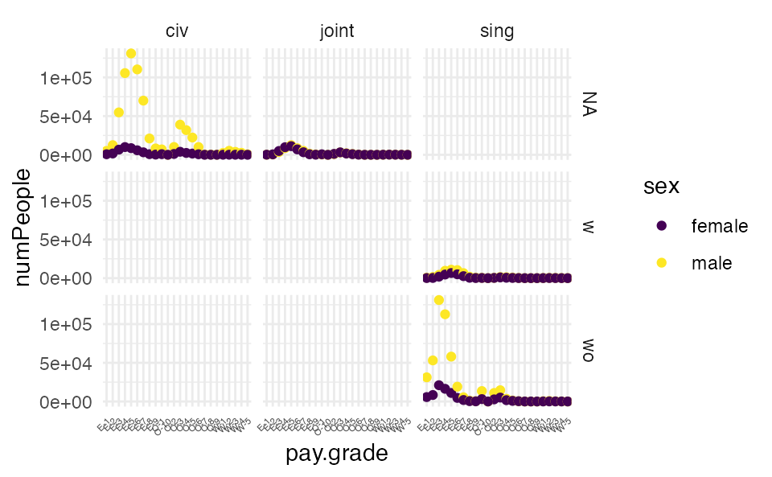

```r
navyWR |>
  ggplot(aes(x = pay.grade, y = numPeople, color = sex)) +
  geom_point() +
  facet_grid(kids ~ marital) +
  theme_minimal() +
  scale_color_viridis_d() +
  theme(
    axis.text.x = element_text(angle = 45, vjust = 1, hjust = 1, size = rel(.5))
  )
```

Notice the difference between `facet_grid()` and `facet_wrap()`.

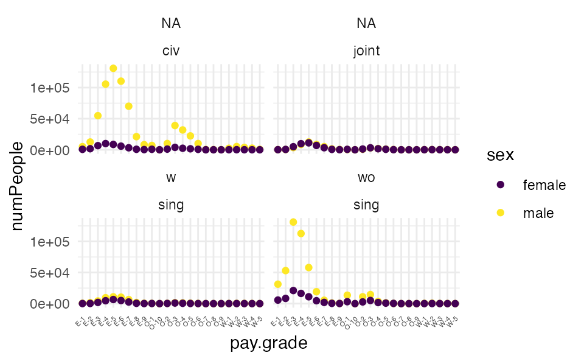

```r
navyWR |>
  ggplot(aes(x = pay.grade, y = numPeople, color = sex)) +
  geom_point() +
  facet_wrap(kids ~ marital) +
  theme_minimal() +
  scale_color_viridis_d() +
  theme(
    axis.text.x = element_text(angle = 45, vjust = 1, hjust = 1, size = rel(.5))
  )
```

### 7.5.2 `pivot_wider`

```r
library(babynames)
babynames |>
  dplyr::select(-prop) |>
  tidyr::pivot_wider(names_from = sex, values_from = n)
```

```
# A tibble: 1,756,284 × 4
   year name          F     M
  <dbl> <chr>     <int> <int>
1  1880 Mary       7065    27
2  1880 Anna       2604    12
3  1880 Emma       2003    10
4  1880 Elizabeth  1939     9
5  1880 Minnie     1746     9
6  1880 Margaret   1578    NA
# ℹ 1,756,278 more rows
```

```r
babynames |>
  select(-prop) |>
  pivot_wider(names_from = sex, values_from = n) |>
  filter(!is.na(F) & !is.na(M)) |>
  arrange(desc(year), desc(M))
```

```
# A tibble: 168,381 × 4
   year name         F     M
  <dbl> <chr>    <int> <int>
1  2017 Liam        36 18728
2  2017 Noah       170 18326
3  2017 William     18 14904
4  2017 James       77 14232
5  2017 Logan     1103 13974
6  2017 Benjamin     8 13733
# ℹ 168,375 more rows
```

```r
babynames |>
  pivot_wider(names_from = sex, values_from = n) |>
  filter(!is.na(F) & !is.na(M)) |>
  arrange(desc(prop))
```

```
# A tibble: 12 × 5
   year name            prop     F     M
  <dbl> <chr>          <dbl> <int> <int>
1  1986 Marquette 0.0000130     24    25
2  1996 Dariel    0.0000115     22    23
3  2014 Laramie   0.0000108     21    22
4  1939 Earnie    0.00000882    10    10
5  1939 Vertis    0.00000882    10    10
6  1921 Vernis    0.00000703     9     8
# ℹ 6 more rows
```

### 7.5.3 `join` (use `join` to **merge** two datasets)

#### 7.5.3.1 First get the data (GapMinder)

Both of the following datasets come from GapMinder. The first represents country, year, and female literacy rate. The second represents country, year, and GDP (in fixed 2000 US$).

```r
gs4_deauth()
litF <- read_sheet(
  "https://docs.google.com/spreadsheets/d/1hDinTIRHQIaZg1RUn6Z_6mo12PtKwEPFIz_mJVF6P5I/pub?gid=0"
)

litF <- litF |>
  select(country = starts_with("Adult"), starts_with("1"), starts_with("2")) |>
  pivot_longer(-country, names_to = "year", values_to = "litRateF") |>
  filter(!is.na(litRateF))
```

```r
gs4_deauth()
GDP <- read_sheet(
  "https://docs.google.com/spreadsheets/d/1RctTQmKB0hzbm1E8rGcufYdMshRdhmYdeL29nXqmvsc/pub?gid=0"
)

GDP <- GDP |>
  select(country = starts_with("Income"), starts_with("1"), starts_with("2")) |>
  pivot_longer(-country, names_to = "year", values_to = "gdp") |>
  filter(!is.na(gdp))
```

```r
head(litF)
```

```
# A tibble: 6 × 3
  country     year  litRateF
  <chr>       <chr>    <dbl>
1 Afghanistan 1979      4.99
2 Afghanistan 2011     13
3 Albania     2001     98.3
4 Albania     2008     94.7
5 Albania     2011     95.7
6 Algeria     1987     35.8
```

```r
head(GDP)
```

```
# A tibble: 6 × 3
  country year    gdp
  <chr>   <chr> <dbl>
1 Albania 1980  1061.
2 Albania 1981  1100.
3 Albania 1982  1111.
4 Albania 1983  1101.
5 Albania 1984  1065.
6 Albania 1985  1060.
```

```r
# left
litGDPleft <- left_join(litF, GDP, by = c("country", "year"))
dim(litGDPleft)
```

```
[1] 571   4
```

```r
sum(is.na(litGDPleft$gdp))
```

```
[1] 66
```

```r
head(litGDPleft)
```

```
# A tibble: 6 × 4
  country     year  litRateF   gdp
  <chr>       <chr>    <dbl> <dbl>
1 Afghanistan 1979      4.99   NA
2 Afghanistan 2011     13      NA
3 Albania     2001     98.3  1282.
4 Albania     2008     94.7  1804.
5 Albania     2011     95.7  1966.
6 Algeria     1987     35.8  1902.
```

```r
# right
litGDPright <- right_join(litF, GDP, by = c("country", "year"))
dim(litGDPright)
```

```
[1] 7988    4
```

```r
sum(is.na(litGDPright$gdp))
```

```
[1] 0
```

```r
head(litGDPright)
```

```
# A tibble: 6 × 4
  country year  litRateF   gdp
  <chr>   <chr>    <dbl> <dbl>
1 Albania 2001      98.3 1282.
2 Albania 2008      94.7 1804.
3 Albania 2011      95.7 1966.
4 Algeria 1987      35.8 1902.
5 Algeria 2002      60.1 1872.
6 Algeria 2006      63.9 2125.
```

```r
# inner
litGDPinner <- inner_join(litF, GDP, by = c("country", "year"))
dim(litGDPinner)
```

```
[1] 505   4
```

```r
sum(is.na(litGDPinner$gdp))
```

```
[1] 0
```

```r
head(litGDPinner)
```

```
# A tibble: 6 × 4
  country year  litRateF   gdp
  <chr>   <chr>    <dbl> <dbl>
1 Albania 2001      98.3 1282.
2 Albania 2008      94.7 1804.
3 Albania 2011      95.7 1966.
4 Algeria 1987      35.8 1902.
5 Algeria 2002      60.1 1872.
6 Algeria 2006      63.9 2125.
```

```r
# full
litGDPfull <- full_join(litF, GDP, by = c("country", "year"))
dim(litGDPfull)
```

```
[1] 8054    4
```

```r
sum(is.na(litGDPfull$gdp))
```

```
[1] 66
```

```r
head(litGDPfull)
```

```
# A tibble: 6 × 4
  country     year  litRateF   gdp
  <chr>       <chr>    <dbl> <dbl>
1 Afghanistan 1979      4.99   NA
2 Afghanistan 2011     13      NA
3 Albania     2001     98.3  1282.
4 Albania     2008     94.7  1804.
5 Albania     2011     95.7  1966.
6 Algeria     1987     35.8  1902.
```

## 7.6 **purrr** for functional programming

We will see the R package **purrr** in greater detail as we go, but for now, let’s get a hint for how it works.

We are going to focus on the `map` family of functions which will just get us started. Lots of other good **purrr** functions like `pluck()` and `accumulate()`.

Much of below is taken from a [tutorial](https://www.rebeccabarter.com/blog/2019-08-19_purrr/) by Rebecca Barter.

The `map` functions are *named* by the **output** the produce. For example:

- `map(.x, .f)` is the main mapping function and returns a list
- `map_df(.x, .f)` returns a data frame
- `map_dbl(.x, .f)` returns a numeric (double) vector
- `map_chr(.x, .f)` returns a character vector
- `map_lgl(.x, .f)` returns a logical vector

Note that the first argument is always the data object and the second object is always the function you want to iteratively apply to each element in the input object.

The **input** to a `map` function is always either a *vector* (like a column), a *list* (which can be non-rectangular), or a *dataframe* (like a rectangle).

A list is a way to hold things which might be very different in shape:

```r
a_list <- list(
  a_number = 5,
  a_vector = c("a", "b", "c"),
  a_dataframe = data.frame(
    a = 1:3,
    b = c("q", "b", "z"),
    c = c("bananas", "are", "so very great")
  )
)

print(a_list)
```

```
$a_number
[1] 5

$a_vector
[1] "a" "b" "c"

$a_dataframe
  a b             c
1 1 q       bananas
2 2 b           are
3 3 z so very great
```

Consider the following function:

```r
add_ten <- function(x) {
  return(x + 10)
}
```

We can `map()` the `add_ten()` function across a vector. Note that the output is a list (the default).

```r
library(tidyverse)
map(.x = c(2, 5, 10), .f = add_ten)
```

```
[[1]]
[1] 12

[[2]]
[1] 15

[[3]]
[1] 20
```

What if we use a different type of input? The default behavior is to still return a list!

```r
data.frame(a = 2, b = 5, c = 10) |>
  map(add_ten)
```

```
$a
[1] 12

$b
[1] 15

$c
[1] 20
```

What if we want a different type of output? We use a different `map()` function, `map_df()`, for example.

```r
data.frame(a = 2, b = 5, c = 10) |>
  map_df(add_ten)
```

```
# A tibble: 1 × 3
      a     b     c
  <dbl> <dbl> <dbl>
1    12    15    20
```

Shorthand lets us get away from pre-defining the function (which will be useful). Use the backslash `\` to indicate that you have a function:

```r
data.frame(a = 2, b = 5, c = 10) |>
  map_df(\(x) x + 10)
```

```
# A tibble: 1 × 3
      a     b     c
  <dbl> <dbl> <dbl>
1    12    15    20
```

Mostly, the backslash will be used for functions we already know:

```r
library(palmerpenguins)
library(broom)

penguins_split <- split(penguins, penguins$species)
penguins_split |>
  map(\(mydata) lm(body_mass_g ~ flipper_length_mm, data = mydata)) |>
  map_df(tidy) # map(tidy)
```

```
# A tibble: 6 × 5
  term              estimate std.error statistic  p.value
  <chr>                <dbl>     <dbl>     <dbl>    <dbl>
1 (Intercept)        -2536.     965.       -2.63 9.48e- 3
2 flipper_length_mm     32.8      5.08      6.47 1.34e- 9
3 (Intercept)        -3037.     997.       -3.05 3.33e- 3
4 flipper_length_mm     34.6      5.09      6.79 3.75e- 9
5 (Intercept)        -6787.    1093.       -6.21 7.65e- 9
6 flipper_length_mm     54.6      5.03     10.9  1.33e-19
```

```r
penguins |>
  group_by(species) |>
  group_map(\(mydata, ...) {
    lm(body_mass_g ~ flipper_length_mm, data = mydata)
  }) |>
  map(tidy) # map_df(tidy)
```

```
[[1]]
# A tibble: 2 × 5
  term              estimate std.error statistic       p.value
  <chr>                <dbl>     <dbl>     <dbl>         <dbl>
1 (Intercept)        -2536.     965.       -2.63 0.00948
2 flipper_length_mm     32.8      5.08      6.47 0.00000000134

[[2]]
# A tibble: 2 × 5
  term              estimate std.error statistic       p.value
  <chr>                <dbl>     <dbl>     <dbl>         <dbl>
1 (Intercept)        -3037.     997.       -3.05 0.00333
2 flipper_length_mm     34.6      5.09      6.79 0.00000000375

[[3]]
# A tibble: 2 × 5
  term              estimate std.error statistic  p.value
  <chr>                <dbl>     <dbl>     <dbl>    <dbl>
1 (Intercept)        -6787.    1093.       -6.21 7.65e- 9
2 flipper_length_mm     54.6      5.03     10.9  1.33e-19
```

## 7.7 Reflection questions

- What are tidy data?
- What does the pipe (`|>`) do?
- What are the input and output of a data verb?
- What is the difference between `pivot_wider()` and `pivot_longer()`?
- Does `group_by()` do anything if it is the last verb in the chain? What does it do if it is followed by a `summarize()` verb?
- What are the differences across the different `join()` functions?
- What does `map()` do? What are the arguments of `map()`?

## 7.8 Ethics considerations

- Why is code style important?
- Is it okay to just remove an observation if some of the information is missing? Why or why not?
- In what way does the pipe (`|>`) help with communication?

## 7.9 References

Gobet, Fernand, and Herbert A. Simon. 1996. “Templates in Chess Memory: A Mechanism for Recalling Several Boards.” *Cognitive Psychology* 31 (1): 1–40. https://doi.org/https://doi.org/10.1006/cogp.1996.0011.

Kaplan, Daniel. 2015. *Data Computing: An Introduction to Wrangling and Visualization with r*. Project Mosaic Books.

Soloway, Elliot, and Kate Ehrlich. 1984. “Empirical Studies of Programming Knowledge.” *IEEE Transactions on Software Engineering* SE-10 (5).

Wickham, Hadley. 2014. “Tidy Data.” *Journal of Statistical Software* 59 (10). http://www.jstatsoft.org/v59/i10/paper.